# NLP with R - Part 4: practice LDA

Sonia Mazzi [ONS - Data Science Campus](https://datasciencecampus.ons.gov.uk)"

26 March, 2020

[figure not shown]

**Required libraries**

We will first load the libraries we will be using in what follows.

If you don’t have the libraries installed you may need to execute this first

```r
install.packages(c("readr", "dplyr", "tidyr", "stringr", "ggplot2", "kableExtra", "formattable", "gridExtra", "tidytext", "textdata", "magick", "circlize", "radarchart", "igraph", "gggraph", "widyr", "topicmodels", "tm"))
```

Now you can load the libraries

```r
library(readr)# read text files
library(dplyr) #data manipulation
library(tidyr)
library(stringr) #manipulate strings
library(ggplot2) #visualizations
library(ggrepel)
library(kableExtra)
library(formattable)
library(tidytext) #text mining
library(magick)
library(circlize)
library(topicmodels)
library(tm)
```

In this part of the course I will give you some indications and you will do the analysis.

**EXERCISE.** Music and Books

This is adapted from https://www.datacamp.com/community/tutorials/ML-NLP-lyric-analysis

To experience the power of topic modeling and classification, we will combine text from Prince’s lyrics and two books: “Machine Learning For Dummies”, and “Why Icebergs Float”, each having over 30,000 (non-distinct) words.

The data is contained in the subfolder “data” in a file called “three-sources_tidy_balanced.csv”. The following conditioning has already been applied:

- scraped the web for lyrics;
- used the `pdf_text()` function from the `pdftools` package to collect the content of the books;
- cleaned all the data, removed stop words, and created the tidy versions using the `tidytext` package;
- combined and balanced the data such that each writer (source) has the same number of words.

Songs and the pages of books are the **documents**.

**Exercise 1.** Read in the data into an object called `three_sources_tidy`, have a glimpse at it and create the Document-Term Matrix (DTM). Store the DTM in the object `three_sources_dtm`.

In order to apply LDA for topic modelling you need to turn the tidy data into a DTM, where each document is a row, and each column is a term.

To do this we use the `cast_dtm()` function from the `tidytext` package.

`cast_dtm()` needs four arguments:

- `data`: the tidy tibble;
- `document`: the column that contains the documents;
- `term`: the column that contains the terms;
- `value`: the column that contains the number of times the term appears in the document.

The syntax is:

`cast_dtm(data, document, term, value)`

To cast the data into DTM format proceed as follows:

1. Read the tidy data in.
2. Count the words in each document.
3. Use `cast_dtm()` to create the DTM object `three_sources_dtm`.

Solution is below.

```r
three_sources_tidy <- read_csv("data/three_sources_tidy_balanced.csv")
```

```r
three_sources_dtm <- three_sources_tidy %>%
  count(document, word, sort = TRUE) %>% #get word count per document to pass to cast_dtm
  ungroup() %>%
  cast_dtm(document, word, n) #create a DTM with docs as rows and words as columns

three_sources_dtm
```

```
## <<DocumentTermMatrix (documents: 1449, terms: 13608)>>
## Non-/sparse entries: 71386/19646606
## Sparsity           : 100%
## Maximal term length: 27
## Weighting          : term frequency (tf)
```

**Exercise 2.** Fit the LDA model with three topics. Save the results of the model fitting in an object called `three_sources_lda`.

You need to use the `LDA()` function.

Solution is below.

```r
three_sources_lda <- LDA(three_sources_dtm, k = 3, control = list(seed = 123))
```

**Exercise 3.** Explore the word-topic probabilities. Tidy the `three_sources_lda` object and extract the $\beta$ parameter for each topic and term, the probability that a certain word is generated by a certain topic. Store the results in an object called `three_sources_beta`. Using `filter()` extract the probability of the term “shake” belongs to each of the topics.

Solution is below.

```r
three_sources_beta <- tidy(three_sources_lda, matrix = "beta")

three_sources_beta %>% filter(term == "shake")
```

| topic | term | beta |
| --- | --- | --- |
| 1 | shake | 5.487500e-245 |
| 2 | shake | 8.550103e-216 |
| 3 | shake | 3.420049e-03 |

**Exercise 4.** Identify possible topic themes with “top words”. Produce a bar plot with the top 15 words, relative to $\beta$, for each topic.

Solution is below

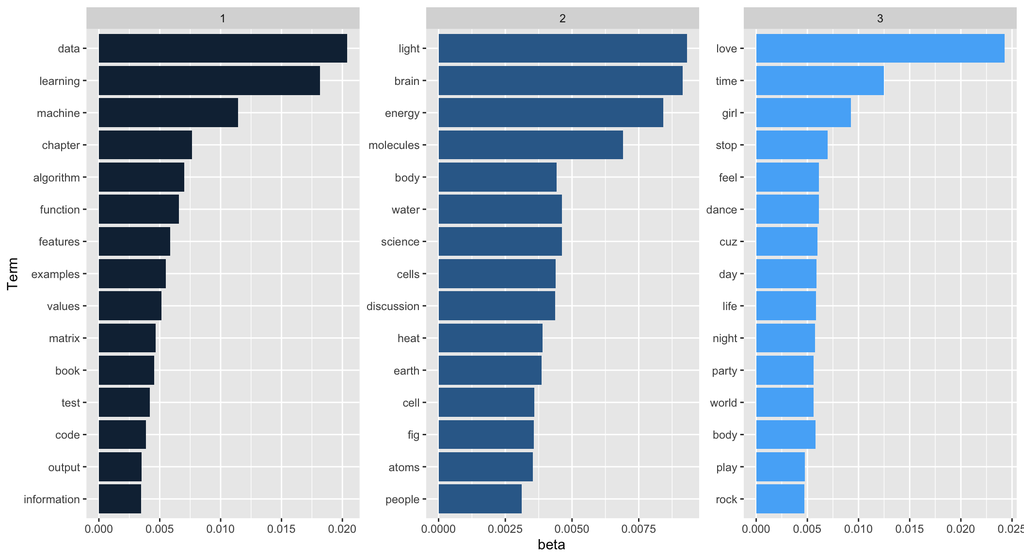

```r
three_sources_beta %>%
  group_by(topic) %>%
  top_n(15, beta) %>%
  ungroup() %>%
  arrange(topic, desc(beta)) %>%
  ggplot(aes(x = reorder(term, beta), y = beta, fill = topic)) +
  geom_col(show.legend = FALSE) +
  facet_wrap(~topic, scales = "free") +
  labs(x = "Term") +
  coord_flip()
```

Unsupervised learning always requires human interpretation. However, these topics clearly reflect the three sources: Topic 1 is Machine Learning, Topic 2 is Icebergs and Topic 3 is Prince.

Solution is below

```r
three_sources_gamma <- tidy(three_sources_lda, matrix = "gamma")

three_sources_gamma %>% filter(document == "purple rain")
```

| document | topic | gamma |
| --- | --- | --- |
| purple rain | 1 | 0.000744481 |
| purple rain | 2 | 0.000744481 |
| purple rain | 3 | 0.998511038 |

The song “Purple rain” belongs to each topic, but at a different percentages, represented by the $\gamma$ value. Some documents fit in some topics better than others. As shown above, “purple rain” has an overwhelmingly higher $\gamma$ value for Topic 3.

**Exercise 6.** Produce a chord diagram that shows the percentage of documents from each source that belong to each topic

In order to create the chord diagram, join the tidy LDA model back to `three_sources_tidy where you stored the actual source (i.e. the writer), and join by document. Then if you do the proper grouping, you can get the average $\gamma$ value per source, per topic.

```r
source_topic_relationship <- three_sources_gamma %>%
  #join to orig tidy data by doc to get the source field
  inner_join(three_sources_tidy, by = "document") %>%
  select(source, topic, gamma) %>%
  group_by(source, topic) %>%
  #get the avg doc gamma value per source/topic
  mutate(mean = mean(gamma)) %>%
  #remove the gamma value as you only need the mean
  select(-gamma) %>%
  ungroup() %>%
  #removing gamma created duplicates so remove them
  distinct()

source_topic_relationship
```

| source | topic | mean |
| --- | --- | --- |
| prince | 1 | 0.004316359 |
| icebergs | 1 | 0.041429485 |
| machine_learning | 1 | 0.987997874 |
| prince | 2 | 0.024550134 |
| icebergs | 2 | 0.950694378 |
| machine_learning | 2 | 0.005665265 |
| prince | 3 | 0.971133506 |
| icebergs | 3 | 0.007876137 |
| machine_learning | 3 | 0.006336861 |

```r
#relabel topics to include the word Topic
#source_topic_relationship$topic = paste("Topic", source_topic_relationship$topic, sep = " ")
source_topic_relationship <- source_topic_relationship %>%
  mutate(topic = paste("Topic", source_topic_relationship$topic, sep = " "))
source_topic_relationship
```

| source | topic | mean |
| --- | --- | --- |
| prince | Topic 1 | 0.004316359 |
| icebergs | Topic 1 | 0.041429485 |
| machine_learning | Topic 1 | 0.987997874 |
| prince | Topic 2 | 0.024550134 |
| icebergs | Topic 2 | 0.950694378 |
| machine_learning | Topic 2 | 0.005665265 |
| prince | Topic 3 | 0.971133506 |
| icebergs | Topic 3 | 0.007876137 |
| machine_learning | Topic 3 | 0.006336861 |

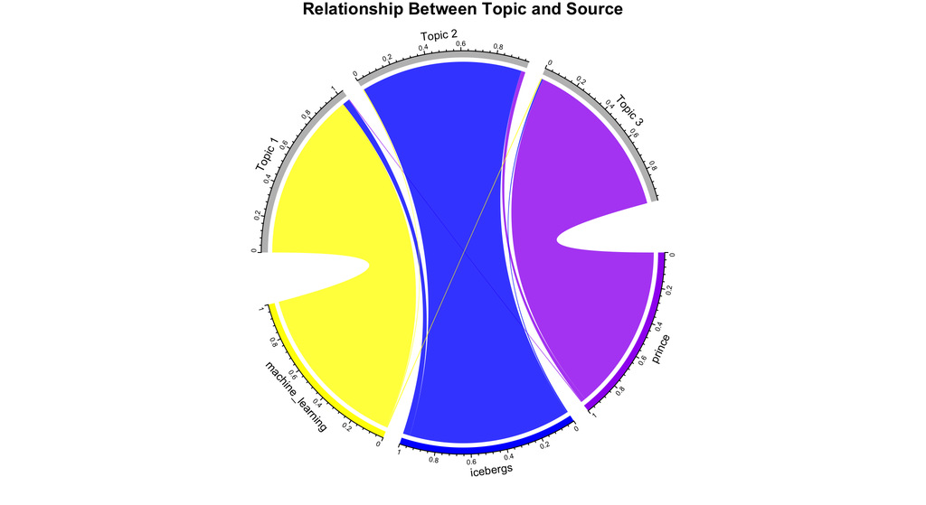

```r
circos.clear() #very important! Reset the circular layout parameters
#assign colors to the outside bars around the circle
grid.col = c("prince" = "purple",
             "icebergs" = "blue",
             "machine_learning" = "yellow",
             "Topic 1" = "grey", "Topic 2" = "grey", "Topic 3" = "grey")

# set the global parameters for the circular layout. Specifically the gap size (15)
#this also determines that topic goes on top half and source on bottom half
circos.par(gap.after = c(rep(5, length(unique(source_topic_relationship[[1]])) - 1), 15,
                         rep(5, length(unique(source_topic_relationship[[2]])) - 1), 15))
#main function that draws the diagram. transparancy goes from 0-1
chordDiagram(source_topic_relationship, grid.col = grid.col, transparency = .2)
title("Relationship Between Topic and Source")
```

If you think about what you have just done, you have actually classified documents into Topics based on the mean of $\gamma$ for a topic/source. If you know the writer of a document, and you know the writer composes most lyrics or books on a specific topic, you might assume that artists of similar genres would fall into the same topics and therefore you can recommend writers that are similar.

**Exercise 7.** Top (relative to $\gamma$) Documents Per Topic

Now look at the individual document level and view the top documents per topic.

```r
k <- 3 #nr of topics
number_of_documents <- 5 #number of top docs to view
title <- paste("LDA Top Documents for", k, "Topics")

#same process as used with the top words
top_documents <- three_sources_gamma %>%
  group_by(topic) %>%
  arrange(topic, desc(gamma)) %>%
  slice(seq_len(number_of_documents)) %>%
  arrange(topic, gamma) %>%
  mutate(row = row_number()) %>%
  ungroup() %>%
  #re-label topics
  mutate(topic = paste("Topic", topic, sep = " ")) %>%
  select(-gamma) %>%
  pivot_wider(names_from = topic, values_from = document) %>%
  select(-row)

top_documents
```

| Topic 1 | Topic 2 | Topic 3 |
| --- | --- | --- |
| page_364 | page72 | jughead |
| page_209 | page49 | push it up |
| page_384 | page164 | the exodus has begun |
| page_339 | page35 | cloreen bacon skin |
| page_308 | page39 | johnny |

**Exercise 8.** The `LDA()` function accepts two methods for fitting the LDA model: “VEM” and “Gibbs”. The default is “VEM”.

Try the same analysis with `LDA(three_sources_dtm, k=3, method = "Gibbs", control = list(seed = 123))`.

Which method do you think works best?

```r
three_sources_lda_gibbs <- LDA(three_sources_dtm, k = 3, method = "Gibbs", control = list(seed = 123))
```

```r
three_sources_beta_gibbs <- tidy(three_sources_lda_gibbs, matrix = "beta")

three_sources_beta_gibbs %>% filter(term == "shake")
```

| topic | term | beta |
| --- | --- | --- |
| 1 | shake | 2.787472e-06 |
| 2 | shake | 3.464356e-03 |
| 3 | shake | 2.917595e-06 |

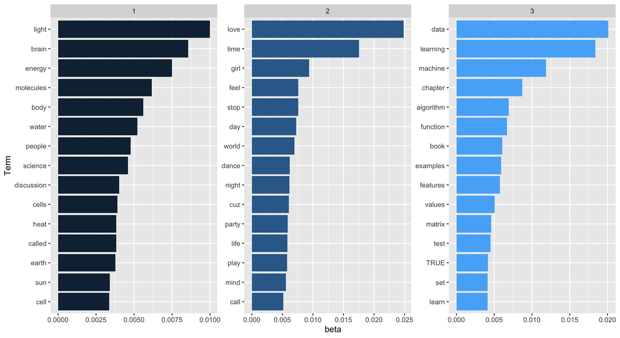

```r
three_sources_beta_gibbs %>%
  group_by(topic) %>%
  top_n(15, beta) %>%
  ungroup() %>%
  arrange(topic, desc(beta)) %>%
  ggplot(aes(x = reorder(term, beta), y = beta, fill = topic)) +
  geom_col(show.legend = FALSE) +
  facet_wrap(~topic, scales = "free") +
  labs(x = "Term") +
  coord_flip()
```

```r
three_sources_gamma_gibbs <- tidy(three_sources_lda_gibbs, matrix = "gamma")

three_sources_gamma_gibbs %>% filter(document == "purple rain")
```

| document | topic | gamma |
| --- | --- | --- |
| purple rain | 1 | 0.2489451 |
| purple rain | 2 | 0.5400844 |
| purple rain | 3 | 0.2109705 |

```r
source_topic_relationship <- three_sources_gamma_gibbs %>%
  #join to orig tidy data by doc to get the source field
  inner_join(three_sources_tidy, by = "document") %>%
  select(source, topic, gamma) %>%
  group_by(source, topic) %>%
  #get the avg doc gamma value per source/topic
  mutate(mean = mean(gamma)) %>%
  #remove the gamma value as you only need the mean
  select(-gamma) %>%
  ungroup() %>%
  #removing gamma created duplicates so remove them
  distinct()

source_topic_relationship
```

| source | topic | mean |
| --- | --- | --- |
| prince | 1 | 0.2309900 |
| icebergs | 1 | 0.6899020 |
| machine_learning | 1 | 0.2044935 |
| prince | 2 | 0.5637607 |
| icebergs | 2 | 0.1431739 |
| machine_learning | 2 | 0.1576610 |
| prince | 3 | 0.2052493 |
| icebergs | 3 | 0.1669241 |
| machine_learning | 3 | 0.6378455 |

```r
#relabel topics to include the word Topic
#source_topic_relationship$topic = paste("Topic", source_topic_relationship$topic, sep = " ")
source_topic_relationship <- source_topic_relationship %>%
  mutate(topic = paste("Topic", source_topic_relationship$topic, sep = " "))
source_topic_relationship
```

| source | topic | mean |
| --- | --- | --- |
| prince | Topic 1 | 0.2309900 |
| icebergs | Topic 1 | 0.6899020 |
| machine_learning | Topic 1 | 0.2044935 |
| prince | Topic 2 | 0.5637607 |
| icebergs | Topic 2 | 0.1431739 |
| machine_learning | Topic 2 | 0.1576610 |
| prince | Topic 3 | 0.2052493 |
| icebergs | Topic 3 | 0.1669241 |
| machine_learning | Topic 3 | 0.6378455 |

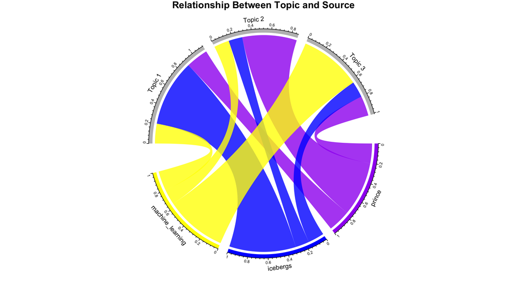

```r
circos.clear() #very important! Reset the circular layout parameters
#assign colors to the outside bars around the circle
grid.col = c("prince" = "purple",
             "icebergs" = "blue",
             "machine_learning" = "yellow",
             "Topic 1" = "grey", "Topic 2" = "grey", "Topic 3" = "grey")

# set the global parameters for the circular layout. Specifically the gap size (15)
#this also determines that topic goes on top half and source on bottom half
circos.par(gap.after = c(rep(5, length(unique(source_topic_relationship[[1]])) - 1), 15,
                         rep(5, length(unique(source_topic_relationship[[2]])) - 1), 15))
#main function that draws the diagram. transparancy goes from 0-1
chordDiagram(source_topic_relationship, grid.col = grid.col, transparency = .2)
title("Relationship Between Topic and Source")
```

```r
k <- 3 #nr of topics
number_of_documents <- 5 #number of top docs to view
title <- paste("LDA Top Documents for", k, "Topics")

#same process as used with the top words
top_documents <- three_sources_gamma_gibbs %>%
  group_by(topic) %>%
  arrange(topic, desc(gamma)) %>%
  slice(seq_len(number_of_documents)) %>%
  arrange(topic, gamma) %>%
  mutate(row = row_number()) %>%
  ungroup() %>%
  #re-label topics
  mutate(topic = paste("Topic", topic, sep = " ")) %>%
  select(-gamma) %>%
  pivot_wider(names_from = topic, values_from = document) %>%
  select(-row)

top_documents
```

| Topic 1 | Topic 2 | Topic 3 |
| --- | --- | --- |
| page34 | rock n roll is alive and it lives in minneapolis | page_70 |
| page219 | push it up | page_394 |
| page145 | goangster glam | page_339 |
| page43 | cloreen bacon skin | page_390 |
| page81 | johnny | page_283 |